# Predicting Shoreline Change Using EOF Analysis and Machine Learning for ShoreShop2

Julian O’Grady, CSIRO ORCID = ‘http://orcid.org/0000-0003-3552-9193’

2024-10-30

## Introduction

This model is named **ShorEOF-ML** (pronounced “shore of ML”) to reflect its focus on shoreline prediction using Empirical Orthogonal Functions (EOF) and Machine Learning (ML).

In this analysis, we explore the use of [**Principal Component Analysis (PCA)**](https://www.coastalwiki.org/wiki/Analysis_of_coastal_processes_with_Empirical_Orthogonal_Functions#Applications_of_Empirical_Orthogonal_Functions_.28EOF.29), specifically through **Empirical Orthogonal Functions (EOFs)**, to model and predict **shoreline change** Short and Trembanis 2004. The goal is to identify key patterns in coastal variability—both spatial (e.g., entire beach retreat/advance or shoreline rotation) and temporal (e.g. changing ocean conditions)—and use these patterns to create a predictive model of shoreline change driven by ocean conditions.

## What is EOF Analysis?

EOF analysis is a powerful tool for decomposing complex spatial-temporal data into simpler patterns. In this case, we use EOFs to capture the primary modes of shoreline variability. These modes may represent large-scale changes, such as:

- **Beach retreat** (the entire shoreline moving landward for positive PC time series values or seaward for negative values).
- **Shoreline rotation** (one side of the shoreline retreats while another advances and vice versa for negative values).

By breaking down the shoreline data into its nine principal components (PCs), we can better understand how the coastline responds to environmental factors like wave energy and water levels. These PCs form the backbone of our model, summarizing the most significant patterns of variability in a compact and interpretable way.

## Machine Learning to Predict Shoreline Change

Once we have the principal components, the next step is to predict these PCs using **machine learning**. We use a variety of oceanographic inputs, such as wave height, wave direction, and water levels, to train a model that can predict future shoreline positions based on these inputs.

The machine learning model attempts to forecast the **PC time series**, which can then be mapped back to the physical shoreline changes using the EOFs. While the predictions show some promise, we are still evaluating the overall accuracy and robustness of the model. The analysis identifies the important ocean factors that drive each of the PCs related to the EOF of shoreline retreat or rotation.

## Inspiration for the Analysis

This work draws inspiration from a range of recent work in coastal modelling:

- **James Thompson**’s [conference presentation](https://scholar.google.com.au/citations?view_op=view_citation&hl=en&user=4vwRMF8AAAAJ&sortby=pubdate&citation_for_view=4vwRMF8AAAAJ:ldfaerwXgEUC), which uses EOF analysis to link shoreline rotation with the **Southern Annular Mode** (a key climate variability driver).
- **Emilio Echevarria**’s [conference presentation](https://ics2024.exordo.com/programme/presentation/175), which combines EOF-based data reduction with machine learning to predict shoreline change from **XBeach** hindcast numerical simulations.
- Discussion with **Stephanie-Contardo** on using lag data (delta changes in conditions) for prediction.

## Ongoing work

While we are still refining the model, this approach offers a promising path forward for predicting coastal change. By combining EOF analysis with machine learning, we can capture complex patterns in coastal systems and link them to oceanographic drivers. The ongoing challenge is to ensure the accuracy and generalizability of the model, especially in the face of dynamic environmental conditions.

Stay tuned as we continue to refine this method and explore its potential for coastal management and shoreline prediction!

## load the packages

```
## This version of gbm is no longer under development. Consider transitioning to gbm3, https://github.com/gbm-developers/gbm3
```

```
## terra 1.7.78
```

[output not shown]

## Read in the data

```r
datadir = "../../datasets/"

transects_coords = read.csv(paste0(datadir,"transects_coords.csv"))
slope = read.csv(paste0(datadir,"slope.csv"))

shorelines_groundtruth = read.csv(paste0(datadir,"shorelines/shorelines_groundtruth.csv"))
shorelines_obs = read.csv(paste0(datadir,"shorelines/shorelines_obs.csv"))
shorelines_target_short = read.csv(paste0(datadir,"shorelines/shorelines_target_short.csv"))
shorelines_target_medium = read.csv(paste0(datadir,"shorelines/shorelines_target_medium.csv"))

tide = read.csv(paste0(datadir,"tide/tide.csv"))

sealevel_obs = read.csv(paste0(datadir,"sealevel/sealevel_obs.csv"))
sealevel_proj = read.csv(paste0(datadir,"sealevel/sealevel_proj.csv"))

Hs_hind = read.csv(paste0(datadir,"hindcast_waves/Hs.csv"))
Tp_hind = read.csv(paste0(datadir,"hindcast_waves/Tp.csv"))
Dir_hind = read.csv(paste0(datadir,"hindcast_waves/Dir.csv"))

Hs_rcp45 = read.csv(paste0(datadir,"forecast_waves/RCP45/Hs.csv"))
Tp_rcp45 = read.csv(paste0(datadir,"forecast_waves/RCP45/Tp.csv"))
Dir_rcp45 = read.csv(paste0(datadir,"forecast_waves/RCP45/Dir.csv"))

Hs_rcp45 = read.csv(paste0(datadir,"forecast_waves/RCP45/Hs.csv"))
Tp_rcp45 = read.csv(paste0(datadir,"forecast_waves/RCP45/Tp.csv"))
Dir_rcp45 = read.csv(paste0(datadir,"forecast_waves/RCP45/Dir.csv"))

Hs_Depth = 10 #m
D50 =  0.3 #mm
DoC =  11 # m
S2c = 0.022 #
dist2DoC = 11/0.022 # m
```

### Plot the transects

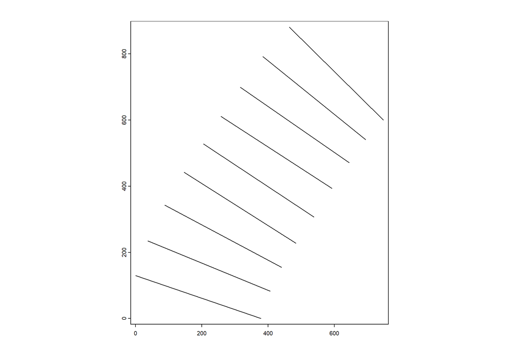

```r
nt =dim(transects_coords)[1]
tm = as.matrix(transects_coords)
trans_v = vect(lapply(1:nt, function(x) vect(rbind(as.numeric(tm[x,][c(2,3)]),
                                                   as.numeric(tm[x,][c(4,5)])),"lines")))
plot(trans_v)
```

```r
transects_coords
```

```
##          ID    Land_x   Land_y    Sea_x     Sea_y
## 1 Transect1 463.81085 880.9246 748.4089 599.88817
## 2 Transect2 383.75655 792.0825 694.6415 540.43333
## 3 Transect3 316.18374 699.2311 644.8331 471.28232
## 4 Transect4 257.52413 610.8527 593.0438 393.11350
## 5 Transect5 204.79909 527.7855 538.5091 307.35621
## 6 Transect6 146.18464 442.4020 483.8709 227.91945
## 7 Transect7  87.90098 342.7144 441.0755 155.00082
## 8 Transect8  36.33544 234.5967 406.4175  82.99303
## 9 Transect9   0.00000 129.8371 378.2408   0.00000
```

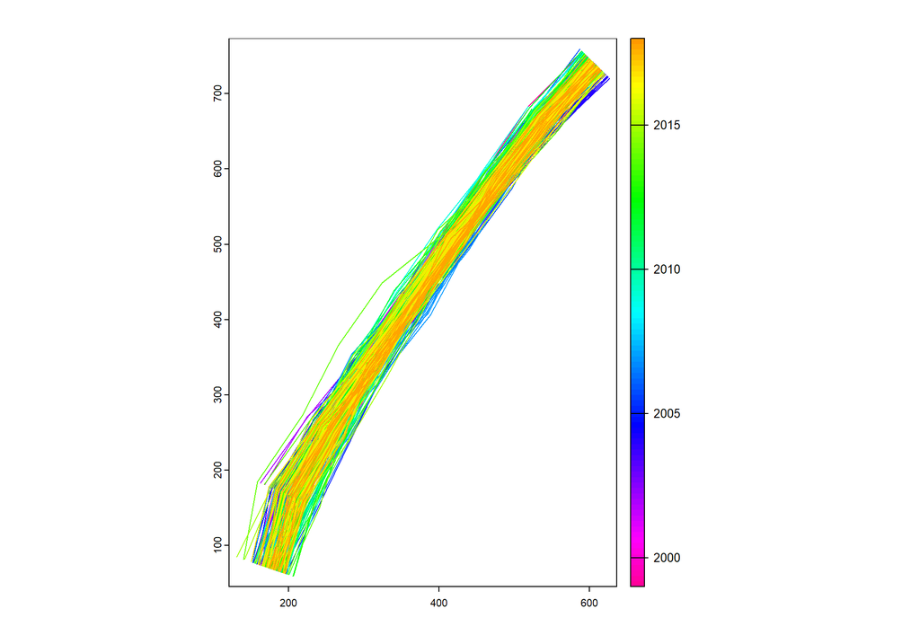

```r
ng = dim(shorelines_obs)[1]
d = c(0,400)
gtx = array(dim = nt)
gty = array(dim = nt)
gt_l = list()
for(j in 1:ng){
  for(i in 1:nt){
    gtx[i] = approx(d,as.numeric(tm[i,][c(2,4)]),shorelines_obs[j,i+1])$y
    gty[i] = approx(d,as.numeric(tm[i,][c(3,5)]),shorelines_obs[j,i+1])$y
  }
  gt_l[[j]] = vect(cbind(gtx,gty),"lines")
}
obs_v = vect(gt_l)
obs_v$Datetime = shorelines_obs$Datetime
obs_v$year = as.numeric(substr(shorelines_obs$Datetime,1,4))
plot(obs_v,"year",type = "continuous")
```

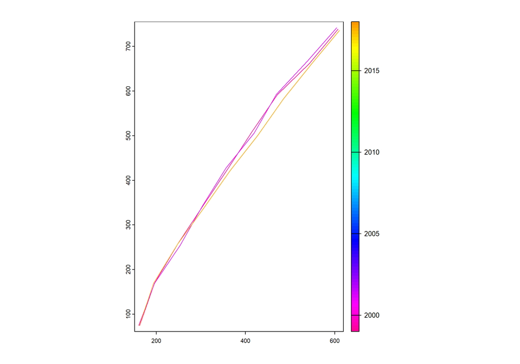

```r
ng = dim(shorelines_groundtruth)[1]
gt_l = list()
for(j in 1:ng){
  for(i in 1:nt){
    gtx[i] = approx(d,as.numeric(tm[i,][c(2,4)]),shorelines_groundtruth[j,i+1])$y
    gty[i] = approx(d,as.numeric(tm[i,][c(3,5)]),shorelines_groundtruth[j,i+1])$y
  }
  gt_l[[j]] = vect(cbind(gtx,gty),"lines")
}
gt_v = vect(gt_l)
gt_v$Datetime = shorelines_groundtruth$Datetime
gt_v$year = as.numeric(substr(shorelines_groundtruth$Datetime,1,4))
plot(gt_v,"year",type = "continuous")
```

## Check how similar the Hs and Dir between profiles using the Pearson correlation.

```r
#check if transect waves are Correlated
cor(Hs_hind[,-1],use = "pairwise.complete.obs")
```

```
##           Transect1 Transect2 Transect3 Transect4 Transect5 Transect6 Transect7
## Transect1 1.0000000 0.9999917 0.9998465 0.9995109 0.9993684 0.9988831 0.9985942
## Transect2 0.9999917 1.0000000 0.9999087 0.9996298 0.9995043 0.9990607 0.9987918
## Transect3 0.9998465 0.9999087 1.0000000 0.9998984 0.9998314 0.9995202 0.9993130
## Transect4 0.9995109 0.9996298 0.9998984 1.0000000 0.9999890 0.9998300 0.9996964
## Transect5 0.9993684 0.9995043 0.9998314 0.9999890 1.0000000 0.9998989 0.9997907
## Transect6 0.9988831 0.9990607 0.9995202 0.9998300 0.9998989 1.0000000 0.9999802
## Transect7 0.9985942 0.9987918 0.9993130 0.9996964 0.9997907 0.9999802 1.0000000
## Transect8 0.9984705 0.9986761 0.9992216 0.9996351 0.9997390 0.9999619 0.9999970
## Transect9 0.9982956 0.9985122 0.9990904 0.9995461 0.9996621 0.9999281 0.9999834
##           Transect8 Transect9
## Transect1 0.9984705 0.9982956
## Transect2 0.9986761 0.9985122
## Transect3 0.9992216 0.9990904
## Transect4 0.9996351 0.9995461
## Transect5 0.9997390 0.9996621
## Transect6 0.9999619 0.9999281
## Transect7 0.9999970 0.9999834
## Transect8 1.0000000 0.9999944
## Transect9 0.9999944 1.0000000
```

```r
cor(Dir_hind[,-1],use = "pairwise.complete.obs")
```

```
##           Transect1 Transect2 Transect3 Transect4 Transect5 Transect6 Transect7
## Transect1 1.0000000 0.9996070 0.9945988 0.9803599 0.9767849 0.9696777 0.9619568
## Transect2 0.9996070 1.0000000 0.9970623 0.9854821 0.9823245 0.9748417 0.9669726
## Transect3 0.9945988 0.9970623 1.0000000 0.9952811 0.9934639 0.9856262 0.9776437
## Transect4 0.9803599 0.9854821 0.9952811 1.0000000 0.9995937 0.9911566 0.9830978
## Transect5 0.9767849 0.9823245 0.9934639 0.9995937 1.0000000 0.9937832 0.9867412
## Transect6 0.9696777 0.9748417 0.9856262 0.9911566 0.9937832 1.0000000 0.9986516
## Transect7 0.9619568 0.9669726 0.9776437 0.9830978 0.9867412 0.9986516 1.0000000
## Transect8 0.9581789 0.9631611 0.9738336 0.9793705 0.9833937 0.9974263 0.9998014
## Transect9 0.9524359 0.9574129 0.9681635 0.9739876 0.9784942 0.9952139 0.9989222
##           Transect8 Transect9
## Transect1 0.9581789 0.9524359
## Transect2 0.9631611 0.9574129
## Transect3 0.9738336 0.9681635
## Transect4 0.9793705 0.9739876
## Transect5 0.9833937 0.9784942
## Transect6 0.9974263 0.9952139
## Transect7 0.9998014 0.9989222
## Transect8 1.0000000 0.9996458
## Transect9 0.9996458 1.0000000
```

## Combine all the data

```r
s = which(as.Date(Hs_rcp45[,1]) > max(as.Date(Hs_hind[,1])))
data_df = data.frame(date = as.Date(c(Hs_hind[,1],Hs_rcp45[,1][s])),
                    Hs = apply(rbind(Hs_hind[,-1],Hs_rcp45[,-1][s,]),1,"mean"),
                    Tp = apply(rbind(Tp_hind[,-1],Tp_rcp45[,-1][s,]),1,"mean"),
                    Dir = apply(rbind(Dir_hind[,-1],Dir_rcp45[,-1][s,]),1,"mean"))


data_df$Dir = data_df$Dir- median(data_df$Dir)
data_df$Dir[data_df$Dir > 180] = data_df$Dir[data_df$Dir > 180] -360
data_df$Dir = data_df$Dir- median(data_df$Dir)

detrend_vector <- function(x) x - lm(x ~ seq_along(x))$fitted.values
data_df$Dir = detrend_vector(data_df$Dir)

data_df$Dir[abs(data_df$Dir) > 45] = 45

data_df <- data_df %>%
  mutate(
    Dir_x = sin((Dir) * pi / 180)*Hs,  # Convert direction to x component
    Dir_y = cos(Dir * pi / 180)*Hs,   # Convert direction to y component
    steepness = Hs/(Tp^2) # wave steepness (Hs/L))
  )

data_df <- data_df %>%
  mutate(
    # Lag features (previous time step)
    lag_Hs = lag(Hs, 1),
    lag_Tp = lag(Tp, 1),
    lag_Dir_x = lag(Dir_x*Hs, 1),
    lag_Dir_y = lag(Dir_y*Hs, 1),
    lag_steepness = lag(Hs/(Tp^2),1)
  )
data_df <- data_df %>% filter(!is.na(lag_Hs))

sealevel_p = sealevel_proj[,c(1,2)]
names(sealevel_p) = names(sealevel_obs)
sealevel_df = rbind(sealevel_obs,sealevel_p)
sealevel_df$date = as.Date(paste0(sealevel_df$Year,"-06-01"))
sealevel_df = rbind(sealevel_df[1,],sealevel_df)
sealevel_df = rbind(sealevel_df,sealevel_df[dim(sealevel_df)[1],])

sealevel_df$date[1] = as.Date(paste0(sealevel_df$Year[1],"-01-01"))
nsl = dim(sealevel_df)[1]
sealevel_df$date[nsl] = as.Date(paste0(sealevel_df$Year[nsl]+1,"-01-01"))
sealevel_df$Year[nsl] = sealevel_df$Year[nsl]+1

data_df$SL = approx(as.numeric(sealevel_df$date),sealevel_df$Sealevel..m.,as.numeric(data_df$date))$y

tide$date = as.Date(tide$Datetime)

data_df$tide = approx(as.numeric(tide$date),tide$Tide..m.,as.numeric(data_df$date))$y


data_df$month = as.numeric(substr(data_df$date,6,7))
```

```r
require(zoo)
```

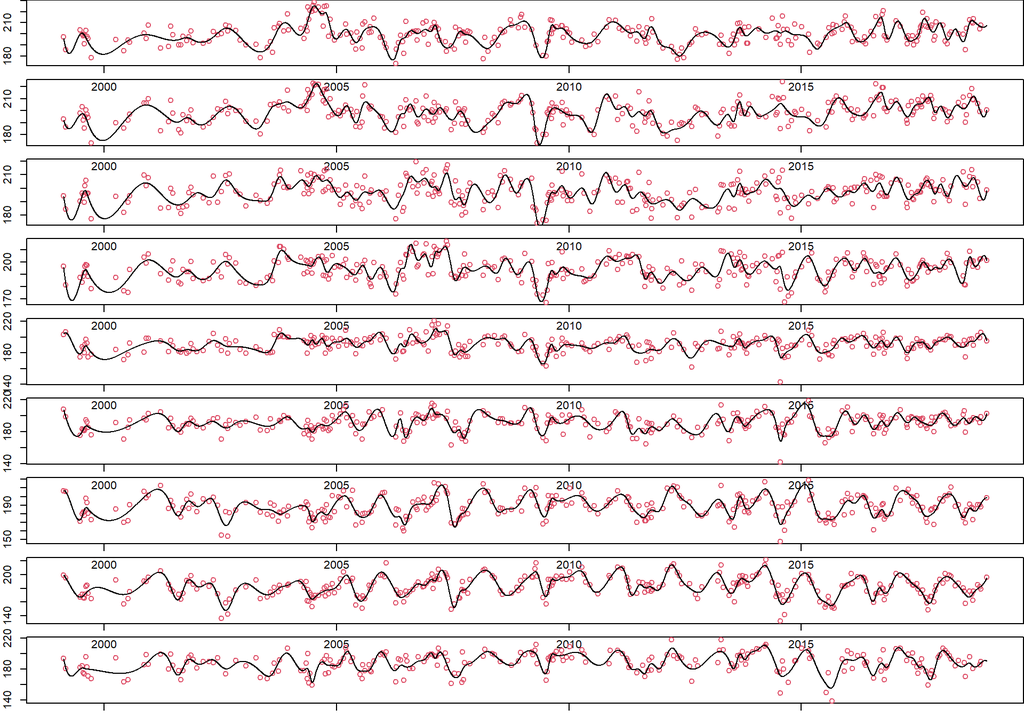

```r
# Step 1: Fill NA values at the start and end using tidyr::fill
shorelines_obs_i <- shorelines_obs[,-1] %>% fill(.direction = "downup")

# Step 2: Interpolate remaining NA values using zoo::na.approx
shorelines_obs_i <- as.data.frame(lapply(shorelines_obs_i, function(col) {
  # Interpolate missing values
  col <- zoo::na.approx(col, na.rm = FALSE)
  # Fill any remaining boundary NA values with the closest non-NA value
  col <- zoo::na.fill(col, fill = "extend")  # Forward and backward fill for boundary NAs
  return(col)
}))

# Step 3: Apply smooth.spline to each column of the interpolated data
tm = as.Date(shorelines_obs$Datetime)
dx_1mSLR= 15
dx = approx(as.numeric(data_df$date),dx_1mSLR*data_df$SL,as.numeric(tm))$y

si = data_df$date >= min(tm) & data_df$date <= max(tm)
tmi = data_df$date[si]

shorelines_obs_s <- as.data.frame(lapply(shorelines_obs_i, function(col) {
  smooth_result <- smooth.spline(x = as.numeric(tm),y = col, spar = 0.01)  # Adjust spar for smoothness (0-1)
  out <- smooth_result$y
  out <- predict(smooth_result,as.numeric(tmi))$y
  #smooth_result <- ksmooth(x = as.numeric(tm), y = col, kernel = "normal", bandwidth = 50)
return(out)
}))
par(mfrow = c(9,1),mar= c(1,2,0,0))
for(i in  1:9){
  plot(tm,shorelines_obs[,i+1])
  points(tm,shorelines_obs[,i+1],col=2)
  lines(tmi,shorelines_obs_s[,i])
}
```

```r
shorelines_obs_raw <- shorelines_obs
#shorelines_obs[,-1] <-  shorelines_obs_s # use the smoothed data
shorelines_obs = cbind(tmi,shorelines_obs_s)
names(shorelines_obs)[1] = "date"
```

# how do the transects change with SLR

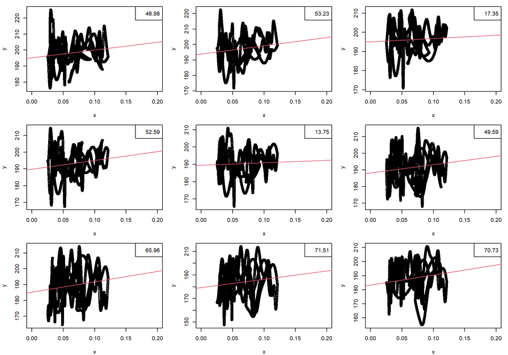

```r
par(mfrow = c(3,3),mar = c(4,4,1,1)+0.01)
dX_dWL = array(dim = 9)
for(i in 1:9) {
  x = approx(as.numeric(data_df$date),data_df$SL,as.numeric(shorelines_obs$date))$y
  y = shorelines_obs[,i+1]
  plot(x,y,xlim = c(0,.2))
  m = lm(y~x)
  dX_dWL[i] = round(m$coefficients[2],2)
  abline(m,col=2)
  legend("topright",legend = dX_dWL[i])
}
```

```r
dx_1mSLR = median(c(1/tan(slope$Slope),dX_dWL))


data_df$SL[si] = detrend_vector(data_df$SL)
```

## Fit the EOFs by centreing the data, then plot a validation of the EOF reconstruction

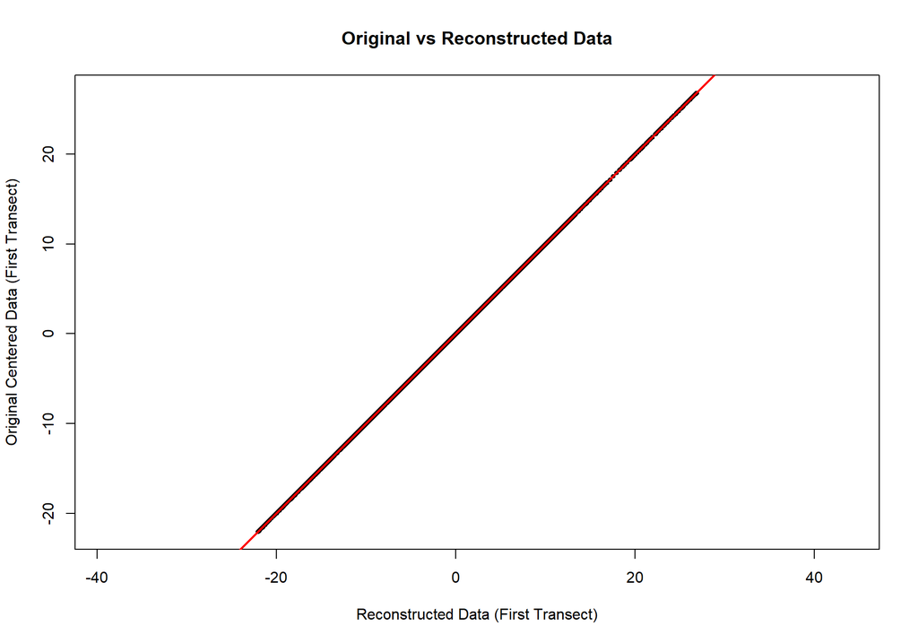

```r
shorelines_obs$date <- as.Date(shorelines_obs[, 1], format = "%Y-%m-%d")
# Convert the first column (date) to Date format (assuming it’s in the first column)
shorelines_obs$date <- as.Date(shorelines_obs[, 1], format = "%Y-%m-%d")  # Adjust format as necessary

# Step 2: Ensure shorelines_data only contains numeric columns (excluding date)
shorelines_data <- shorelines_obs %>% select_if(is.numeric)

# Step 3: Center the numeric data by subtracting the mean of each column (transect data)
shorelines_centered <- scale(shorelines_data, center = TRUE, scale = FALSE)

# Step 4: Check for and handle missing or infinite values
# Replace missing values (NA) with the column mean
shorelines_centered[is.na(shorelines_centered)] <- apply(shorelines_centered, 2, function(col) mean(col, na.rm = TRUE))

# Handle infinite values by replacing them with the column mean
shorelines_centered[is.infinite(shorelines_centered)] <- apply(shorelines_centered, 2, function(col) mean(col[is.finite(col)], na.rm = TRUE))

center_values <- attr(shorelines_centered, "scaled:center")


# Perform SVD on the centered data
svd_result <- svd(shorelines_centered)

# Extract the EOFs (spatial patterns) and PCs (time series)
EOFs <- svd_result$v   # Eigenvectors corresponding to spatial patterns (EOFs)
PCs <- svd_result$u     # PCs are stored in the 'u' matrix (time series)
D <- diag(svd_result$d) # Diagonal matrix of singular values

# Reconstruct the original data using all PCs and EOFs
# The full reconstruction formula should use the singular values as well
rcon_full <- PCs %*% D %*% t(EOFs)

# If shorelines_centered was centered (mean subtracted), add the mean back
rcon_full <- rcon_full #+ attr(shorelines_centered, "scaled:center")

# Compare the first column of the reconstructed data with the original centered data
plot(rcon_full[, 1], shorelines_centered[, 1],
     xlab = "Reconstructed Data (First Transect)",
     ylab = "Original Centered Data (First Transect)",
     main = "Original vs Reconstructed Data",
     pch = 19, cex = 0.6,asp=1)
abline(0, 1, col = "red", lwd = 2)  # Perfect prediction line
```

```r
PCs_with_date <- data.frame(date = shorelines_obs$date, PCs)

names(PCs_with_date) = c("date",paste("PC",1:nt,sep=""))

data_with_PCs <- merge(data_df, PCs_with_date, by = "date")

data_with_PCs_trans = merge(data_with_PCs,shorelines_obs,by = "date")
```

## Plot the spatial EOFs

The first EOF is all positive, the second shows a rotated beach, the third looks like a standing wave with two nodes, and the forth has three nodes.

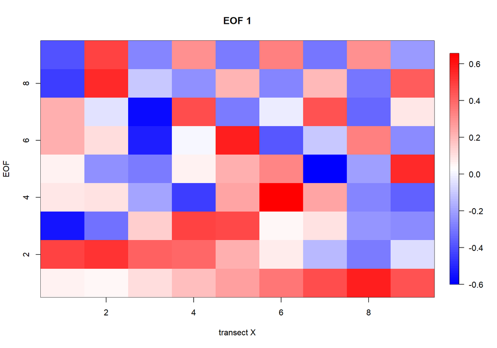

```r
# Define the custom color palette (red -> white -> blue, centered at zero)
custom_palette <- colorRampPalette(c("blue", "white", "red"))(100)

# Get the range of values in EOFs to center the colors around zero
zlim <- range(EOFs)

# Define x and y axis values from 1 to 9 (assuming 9x9 grid for EOFs)
x_vals <- 1:9
y_vals <- 1:9

# Plot the first EOF with x and y axes ranging from 1 to 9
image.plot(x_vals, y_vals, EOFs,  # Reshape EOF to a 9x9 grid
           col = custom_palette,                        # Custom color palette
           xlab = "transect X",
           ylab = "EOF",
           main = "EOF 1",
           zlim = zlim)                                 # Ensure color scale is centered on zero
```

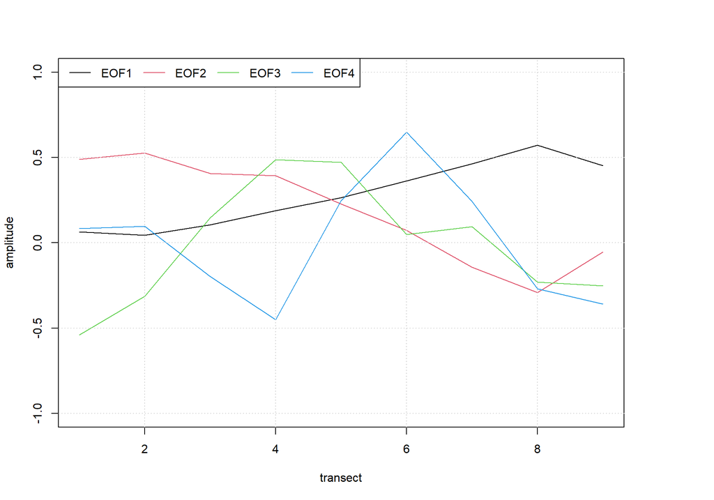

```r
plot(EOFs[,1],ylim = c(-1,1),type="l",ylab = "amplitude",xlab = "transect")
for(i in 2:4) lines(EOFs[,i],col = i)
grid()
legend("topleft",paste0("EOF",1:4),col=1:4,lty=1,ncol=4)
```

## Use the ML model to fit the ocean conditions to the PC for a training **subset** and then predict the shoreline for the remainder of the observed shorelines.

```r
# Custom loss function with the corrected formula
custom_loss <- function(preds, dtrain) {
  # Get the actual labels (observations/targets)
  labels <- getinfo(dtrain, "label")

  # Calculate the standard deviation of the target (observation)
  std_target <- sd(labels)

  if (std_target == 0) {
    stop("The standard deviation of the labels (target) is zero. Correlation cannot be computed.")
  }

  # Compute RMSE and normalize by the standard deviation of the target
  rmse_value <- rmse(labels, preds)
  rmse_norm <- rmse_value / std_target

  # Compute standard deviation of predictions and normalize it
  std_pred <- sd(preds)

  # Handle case where the std of predictions is zero
  if (std_pred == 0) {
    std_norm <- 0  # Assign normalized STD as 0 if no variance in predictions
  } else {
    std_norm <- std_pred / std_target
  }

  # Compute correlation between predictions and actual values
  if (std_pred == 0 || std_target == 0) {
    corr_value <- 0  # Assign correlation as 0 if no variance in either preds or labels
  } else {
    corr_value <- cor(preds, labels)
  }

  # Compute loss L_i with the corrected formula
  Li <- sqrt((0 - rmse_norm)^2 + (1 - corr_value)^2 + (1 - std_norm)^2)

  # For gradient (just a placeholder, real implementation needs analytical gradients)
  grad <- 2 * (preds - labels)  # Simplified gradient placeholder
  hess <- rep(1, length(preds))  # Simplified hessian placeholder

  return(list(grad = grad, hess = hess))
}
```

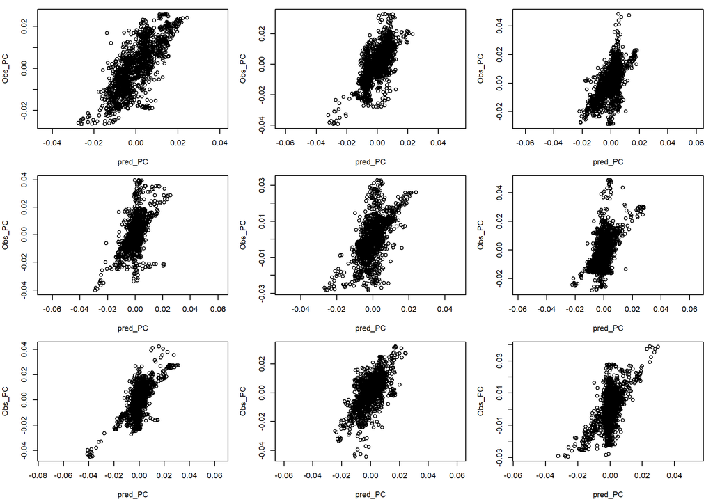

```r
# Split the data into training and test sets
set.seed(123)  # For reproducibility
train_indices <- sample(1:nrow(data_with_PCs), 0.8 * nrow(data_with_PCs))
train_data <- data_with_PCs[train_indices, ]
test_data <- data_with_PCs[-train_indices, ]

shorelines_test = data_with_PCs_trans[-train_indices,]

# Initialize a data.frame to store the predictions for all 9 PCs
predicted_PCs_xgb <- data.frame(matrix(ncol = 9, nrow = nrow(test_data)))
colnames(predicted_PCs_xgb) <- paste0("PC", 1:9)  # Name the columns PC1, PC2, ..., PC9

# Loop over all 9 PCs (PC1 to PC9) to train and predict each one using XGBoost
imp.l = list()

all_pcs <- paste0("PC", 1:9)

# Loop over all 9 PCs (PC1 to PC9) to train and predict each one using XGBoost
for (i in 1:9) {

  # Get the current PC name (PC1, PC2, ..., PC9)
  pc_name <- paste0("PC", i)

  # Prepare the data for XGBoost: remove all other PCs and the date column from the feature matrix
  train_matrix <- as.matrix(train_data[, !names(train_data) %in% c(all_pcs, "date")])
  test_matrix  <- as.matrix(test_data[, !names(test_data) %in% c(all_pcs, "date")])

  # Create DMatrix for XGBoost
  dtrain <- xgb.DMatrix(data = train_matrix, label = train_data[[pc_name]])
  dtest  <- xgb.DMatrix(data = test_matrix)

  # Train the XGBoost model for the current PC
  xgb_model <- xgboost(
    data = dtrain,
    nrounds = 1000,              # Number of boosting rounds
    objective = custom_loss, #"reg:absoluteerror",  # Regression task
    max_depth = 4,               # Depth of each tree
    eta = 0.01,                  # Learning rate (shrinkage)
    verbose = 0                  # Suppress output
  )

  # Predict the current PC on the test data
  predicted_pc_xgb <- predict(xgb_model, newdata = dtest)

  # Store the predictions in the corresponding column of the data.frame
  predicted_PCs_xgb[, pc_name] <- predicted_pc_xgb

  importance_matrix <- xgb.importance(model = xgb_model)
  imp.l[[i]] = importance_matrix
}

# View the first few rows of predicted PCs
#head(predicted_PCs_xgb)

par(mfrow = c(3,3),mar = c(4,4,1,1)+0.01)
for(i in 1:9) plot(predicted_PCs_xgb[[paste0("PC",i)]],test_data[[paste0("PC",i)]],asp=1,xlab = "pred_PC",ylab = "Obs_PC")
```

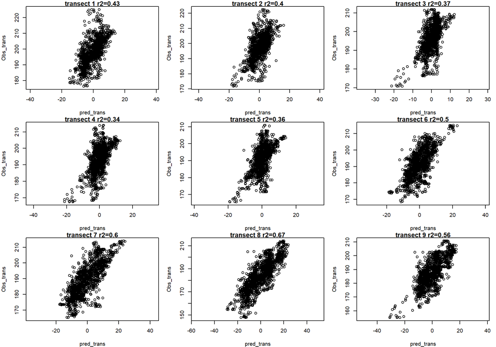

```r
rcon_pred <- as.matrix(predicted_PCs_xgb) %*% D %*% t(EOFs)

r2 = round(sapply(1:9, function(i) cor(rcon_pred[,i],shorelines_test[[paste0("Transect",i)]],use = "pairwise.complete.obs"))^2,2)

rmse <- function(actual, predicted) {
  sqrt(mean((actual - predicted) ^ 2,na.rm=TRUE))
}

fitscale = sapply(1:9, function(i) mean((shorelines_test[[paste0("Transect",i)]]-center_values[i])/
                                   (rcon_pred[,i]),na.rm=TRUE))
RMSE = round(sapply(1:9, function(i) rmse(shorelines_test[[paste0("Transect",i)]],rcon_pred[,i]+center_values[i])),2)


par(mfrow = c(3,3),mar = c(4,4,1,1)+0.01)
for(i in 1:9) plot(rcon_pred[,i],shorelines_test[[paste0("Transect",i)]],asp=1,main = paste0("transect ",i," r2=",r2[i]),xlab = "pred_trans",ylab = "Obs_trans")
```

## plot the importance of each factor when fitting a **subset** of the dataset to test the model

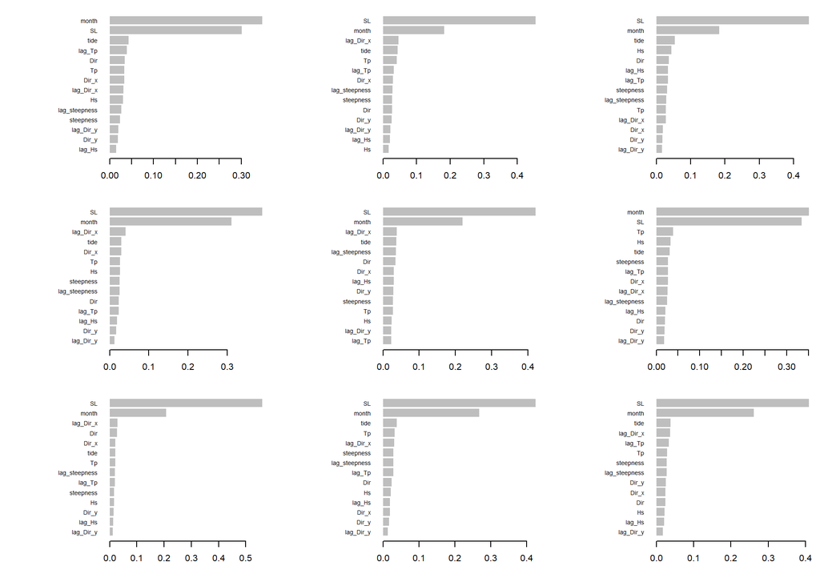

```r
par(mfrow = c(3,3),mar = c(3,3,1,1)+0.01)

for(i in 1:9) xgb.plot.importance(imp.l[[i]])
```

## Use the ML model to fit the ocean conditions to the PC for **all data**

```r
train_data_full <- data_with_PCs
all_pcs <- paste0("PC", 1:9)
xgb_models_l = list()
# Loop over all 9 PCs (PC1 to PC9) to train and predict each one using XGBoost
imp_all.l = list()
for (i in 1:9) {

  # Get the current PC name (PC1, PC2, ..., PC9)
  pc_name <- paste0("PC", i)

  # Prepare the data for XGBoost: remove all other PCs and the date column from the feature matrix
  train_matrix <- as.matrix(train_data_full[, !names(train_data_full) %in% c(all_pcs, "date")])

  # Create DMatrix for XGBoost
  dtrain <- xgb.DMatrix(data = train_matrix, label = train_data_full[[pc_name]])

  # Train the XGBoost model for the current PC
  xgb_model <- xgboost(
    data = dtrain,
    nrounds = 1000,              # Number of boosting rounds
    objective = custom_loss, #"reg:absoluteerror",  # Regression task
    max_depth = 4,               # Depth of each tree
    eta = 0.01,                  # Learning rate (shrinkage)
    verbose = 0                  # Suppress output
  )

  xgb_models_l[[i]] = xgb_model
  importance_matrix <- xgb.importance(model = xgb_model)
  imp_all.l[[i]] = importance_matrix


}
```

## plot the importance of each factor when fitting **all** data

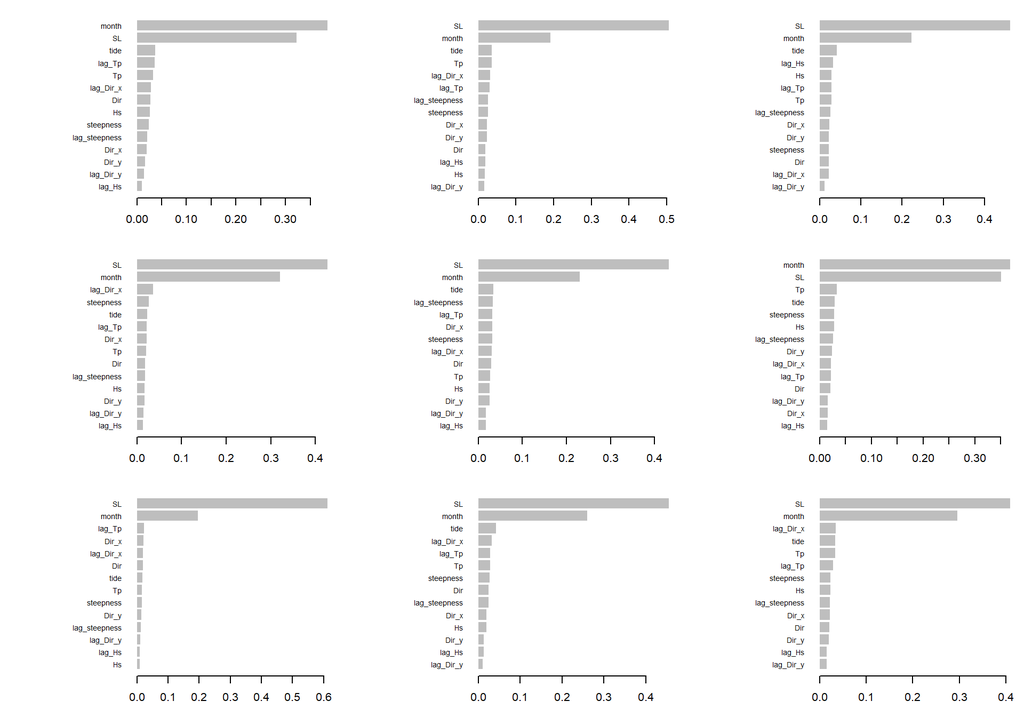

```r
par(mfrow = c(3,3),mar = c(3,3,1,1)+0.01)

for(i in 1:9) xgb.plot.importance(imp_all.l[[i]])
```

## Predict the short medium and long term daily transect data

```r
# Split the data into training and test sets
set.seed(123)  # For reproducibility

period_dates = as.Date(c("2019-01-01","2023-12-31"))

output_csv = function(period_dates,filename){

  test_data <- data_df[data_df$date >= period_dates[1] &
                       data_df$date <= period_dates[2] , ]

  shorelines_test = data_with_PCs_trans[-train_indices,]

  # Initialize a data.frame to store the predictions for all 9 PCs
  predicted_PCs_xgb <- data.frame(matrix(ncol = 9, nrow = nrow(test_data)))
  colnames(predicted_PCs_xgb) <- paste0("PC", 1:9)  # Name the columns PC1, PC2, ..., PC9

  all_pcs <- paste0("PC", 1:9)

  # Loop over all 9 PCs (PC1 to PC9) to train and predict each one using XGBoost
  for (i in 1:9) {

    # Get the current PC name (PC1, PC2, ..., PC9)
    pc_name <- paste0("PC", i)

    # Prepare the data for XGBoost: remove all other PCs and the date column from the feature matrix
    test_matrix  <- as.matrix(test_data[, !names(test_data) %in% c(all_pcs, "date")])

    # Create DMatrix for XGBoost
    dtest  <- xgb.DMatrix(data = test_matrix)

    # Train the XGBoost model for the current PC
    xgb_model <- xgb_models_l[[i]]

    # Predict the current PC on the test data
    predicted_pc_xgb <- predict(xgb_model, newdata = dtest)

    # Store the predictions in the corresponding column of the data.frame
    predicted_PCs_xgb[, pc_name] <- predicted_pc_xgb
  }

  # View the first few rows of predicted PCs
  #head(predicted_PCs_xgb)

  rcon_pred <- as.matrix(predicted_PCs_xgb) %*% D %*% t(EOFs)

  for(i in 1:9) rcon_pred[,i] = rcon_pred[,i] + center_values[i] #+ test_data$SL*dx_1mSLR

  out = as.data.frame(cbind(format(test_data$date,"%Y-%m-%d"),rcon_pred))


  names(out) = c("Datetime",paste0("Transect",1:9))
  write.csv(out,file = filename,row.names = FALSE,quote = FALSE)
}

output_csv(period_dates= as.Date(c("2019-01-01","2023-12-31")),filename = "../../submissions/ShorEOF-ML_corrected_JO/shorelines_prediction_short.csv")
output_csv(period_dates= as.Date(c("1951-05-01","1998-12-31")),filename = "../../submissions/ShorEOF-ML_corrected_JO/shorelines_prediction_medium.csv")
output_csv(period_dates= as.Date(c("2019-01-01","2100-12-31")),filename = "../../submissions/ShorEOF-ML_corrected_JO/shorelines_prediction_long.csv")

output_csv(period_dates= as.Date(c("1999-02-17","2018-12-30")),filename = "../../submissions/ShorEOF-ML_corrected_JO/shorelines_prediction_obs.csv")
```

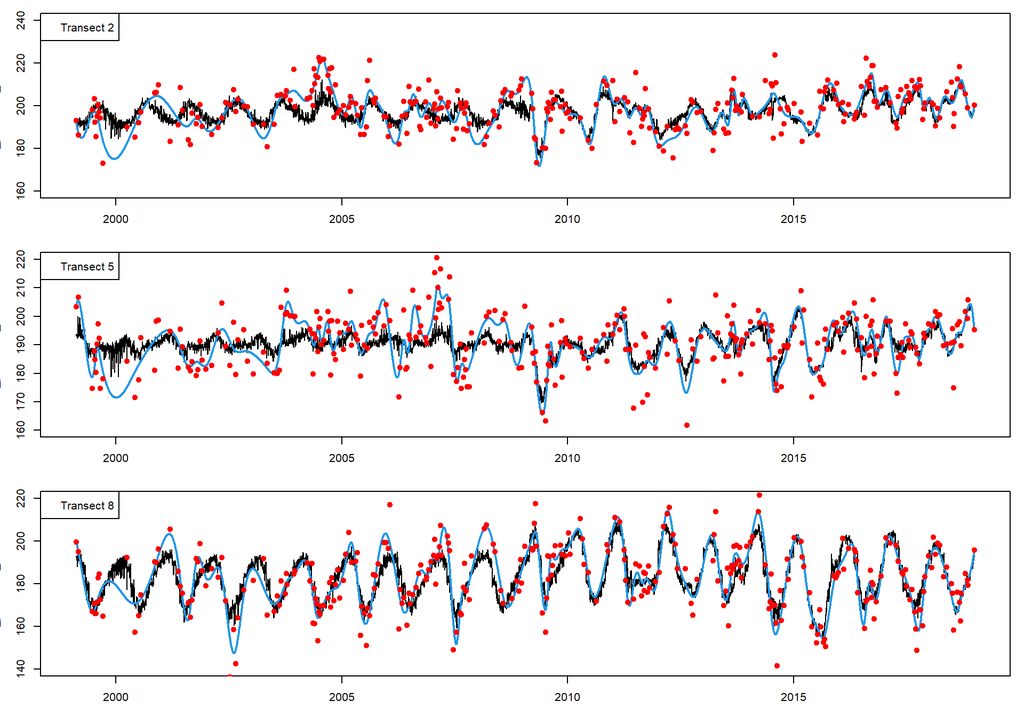

```r
shorelines_prediction_obs = read.csv("../../submissions/ShorEOF-ML_corrected_JO/shorelines_prediction_obs.csv")
shorelines_prediction_obs$date = as.Date(shorelines_prediction_obs$Datetime)

par(mfrow = c(3,1),mar = c(3,3,1,1)+0.01)
plot(shorelines_prediction_obs$date,shorelines_prediction_obs$Transect2,type = "l",ylim = c(160,240))
lines(shorelines_obs$date,shorelines_obs$Transect2,col=4,lwd=2)
points(as.Date(shorelines_obs_raw$Datetime),shorelines_obs_raw$Transect2,col="red",pch=19)
legend("topleft","Transect 2")
plot(shorelines_prediction_obs$date,shorelines_prediction_obs$Transect5,type = "l",ylim = c(160,220))
lines(shorelines_obs$date,shorelines_obs$Transect5,col=4,lwd=2)
points(as.Date(shorelines_obs_raw$Datetime),shorelines_obs_raw$Transect5,col="red",pch=19)
legend("topleft","Transect 5")
plot(shorelines_prediction_obs$date,shorelines_prediction_obs$Transect8,type = "l",ylim = c(140,220))
lines(shorelines_obs$date,shorelines_obs$Transect8,col=4,lwd=2)
points(as.Date(shorelines_obs_raw$Datetime),shorelines_obs_raw$Transect8,col="red",pch=19)
legend("topleft","Transect 8")
```